# WK1 BI tools linked to the decision making process

[interactive chart not shown]

BI tools linked to the decision making process

passionned.com

/business-intelligence-tools-and-the-desicion-making-process

Produce good BI results

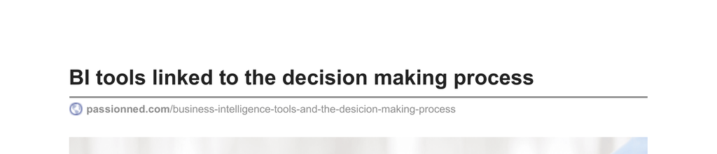

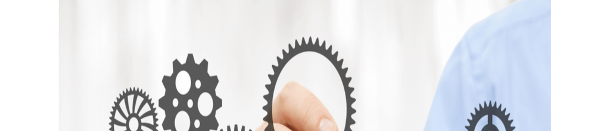

[figure not shown]

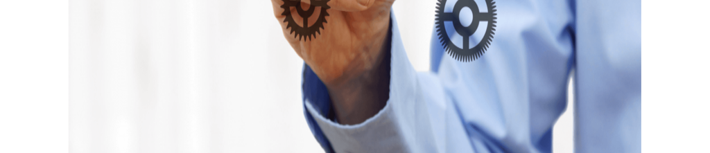

[figure not shown]

[figure not shown]

The Business Intelligence architecture will not be able to produce good results if we cannot

link tools to it. This blog provides an overview of the most important

Business Intelligence

tools (BI Tools)

in relation to the decision-making cycle. It also describes the purposes, the

features and the workings of these tools.

The decision making process

Each Business Intelligence Tool plays a supporting role in one or more phases of the

decision-making cycle. The decision-making cycle comprises of the following phases, which

can be supported by the following tools (see figure below):

Collecting information using dashboards and reports

The decision-making cycle starts with gathering the right information: ‘scanning’ the

environment (or the internal organization) in order to see if a problem exists. Mainly

dashboards

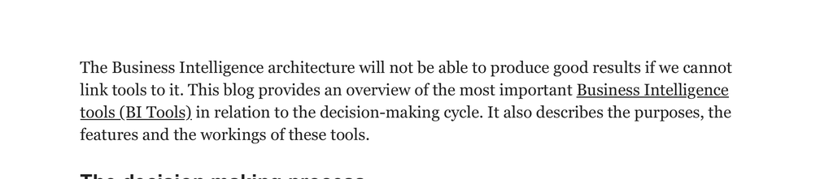

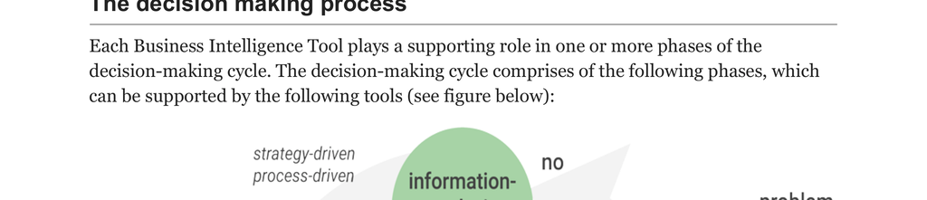

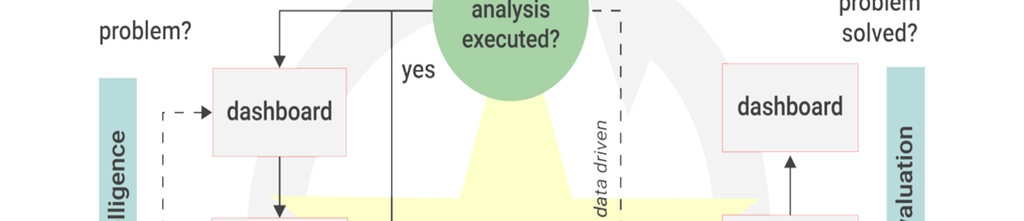

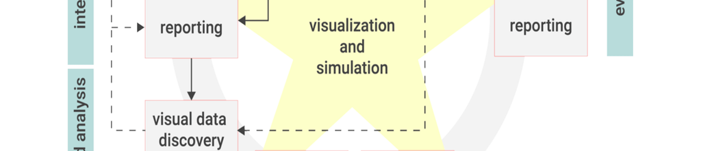

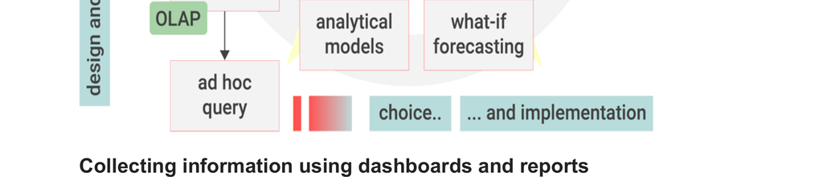

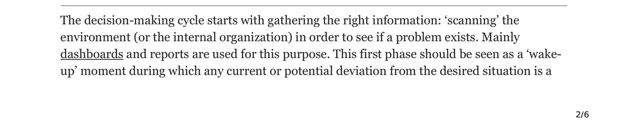

decision problem. In order to qualify or trace something as a problem, the first phase should

– in principle – include (or be preceded by) a process in which we identify our organizational

objectives.

Designing and analyzing using interactive analysis and data mining

Once a problem is discovered, we know where the issue resides but we do not yet know its

exact location or its whys and wherefores. For example: the customer satisfaction indicator

on the dashboard flashes. Subsequently, we will want to find out what causes this. We may,

for example, use interactive analysis ‘on-the-fly’ to split out customer satisfaction per region,

per account manager and, if necessary, per product group.

OLAP

complaints with the customer satisfaction in the same region and period. By doing this, we

gain insight into the reasons why customers are less satisfied – a recently launched product

exhibiting start-up problems, to name a random example. We use data mining – discovering

‘hidden’ relationships – to gain insight into characteristics that are a determining factor for

more complex issues such as fraud. In such cases, interactive analysis is not sufficient

because we generally lack the required detail data. In addition, the complexity associated

with discovering such (causal) relationships is simply a bridge too far for interactive analysis.

Very crucial for strategic decision making

“This phase in the decision-making process seems to be crucial for strategic decision-

making, because it is during this phase that we determine our entire course in terms of

decision-making.”

(Mintzberg, 2004). It is thus important to apply these tools well and to

adjust the organization accordingly. This also means that an effective working relationship

should arise between managers and analysts so that the intuition and the authority of the

managers can go together with the analytical brain of the analyst and with the methods and

functionalities available to him (or her).

Selecting and implementing using ad hoc query

forecasting

Once we have established the cause of a problem and we have mapped the (causal)

relationships, we can take action – in consultation with managers and stakeholders. Ad hoc

query (‘ad hoc’ querying of data sets) can support this. We may for example use ad hoc query

to create a detailed set of customers whom did not place any orders in the last month, based

on the results of the interactive analysis. Subsequently, we can write a letter to the selected

customers in which we emphasize the benefits of doing business with us and include some

interesting offers. We use ‘what-if’ and forecasting in order to calculate actions in advance. In

this way, we gain insight into the impact of our actions before we actually implement them.

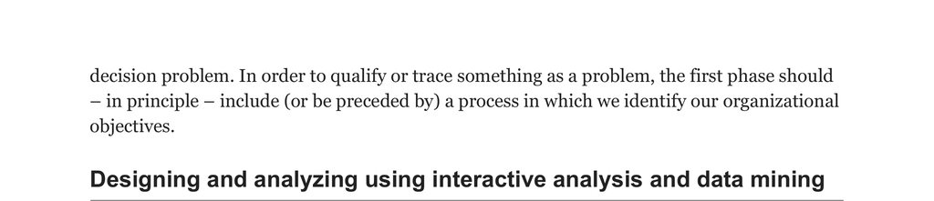

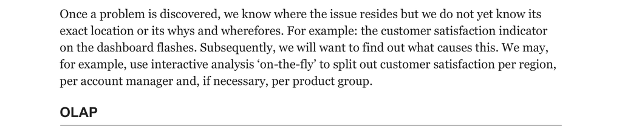

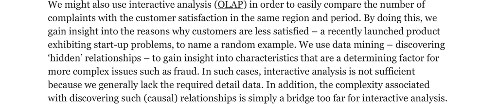

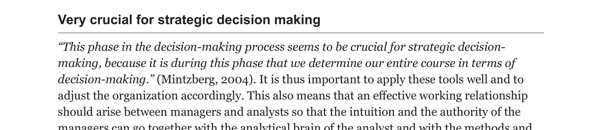

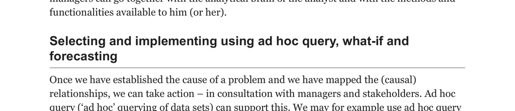

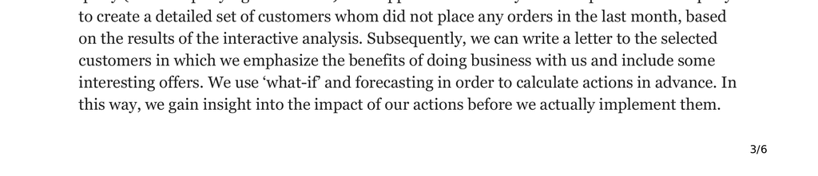

Evaluating using dashboards and reports

Once we addressed a certain problem by taking action, we use either a dashboard or reports

in order to assess whether the problem has indeed been resolved. It may be that the problem

reflects a key success factor of the organization, which we did not know about yet. If this is

the case, we can place the key success factor – including the associated

KPI

– on the

dashboard or in the report so to permanently evaluate it. In this way, it becomes an integral

part of the organization’s management model.

Separate components that are hardly related

Relatively many organizations still appear to regard the above-mentioned tools as separate

components that are hardly related. For

Business Intelligence

to be effective, it is however, of

the utmost importance that the tools can work together very closely so creating a solid and

smoothly operating entity. Users should ideally be able to both use and apply the tools more

or less unwittingly in their daily activities. Metadata, web technology and a proper

architecture play an important role in achieving this.

Increase the coherence between the tools

Additionally, the suppliers of BI tools undertake actions – based on the integral needs

expressed by users – to increase the coherence between different tools. Portals are a typical

example of this development. However, we cannot start celebrating yet: practice shows that

when it comes to integration of different tools within the portal, there is still a lot to be

desired. Unfortunately, it also still happens that certain functionalities are present in the

desktop version , but have not yet been implemented in the web version.

Comment on this post by Daan van Beek

July, 12 2013

by

Daan van Beek

- Updated: December, 28 2019

Filed under:

Decision management

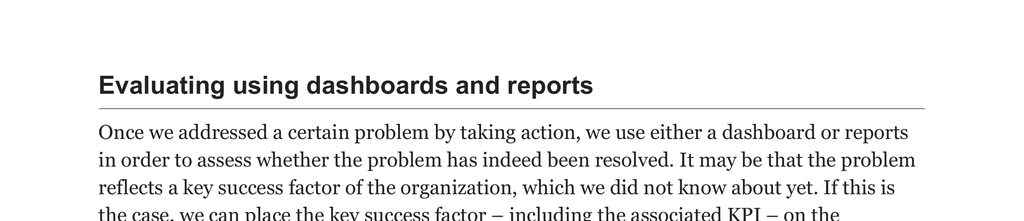

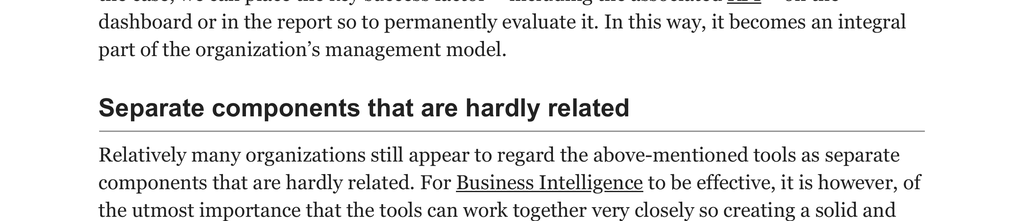

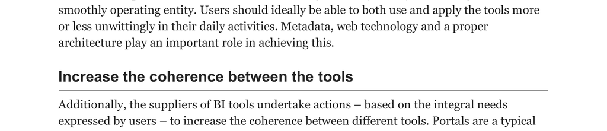

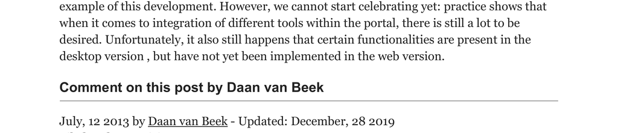

[figure not shown]

[figure not shown]

[figure not shown]

[figure not shown]

[figure not shown]

[figure not shown]

[figure not shown]

[figure not shown]

[figure not shown]

[figure not shown]

[figure not shown]